# Combined MS and MS/MS deconvolution of SWATH DIA data with the DIA-NMF workflow for comprehensive annotation in metabolomics

Diana Karaki

2025-07-21

#### Package

DIANMF 0.1.0

```r
library(DIANMF)
```

**DIANMF**

# 1 Introduction

Liquid chromatography coupled to High Resolution Mass spectrometry (LC-HRMS) is a leading analytical strategy for discovering metabolomics biomarkers in health and disease. In particular, tandem mass spectrometry (LC-HRMS/MS) enables the structural characterization of metabolites by acquiring fragmentation spectra (MS2). Among recent advances, **D**ata **I**ndependent **A**cquisition (DIA), and especially **S**equential **W**indow **A**cquisition of all **TH**eoretical Mass spectrometry (SWATH)-type (Wang, Yin, and Zhu 2019), offer high-throughput and comprehensive MS/MS data scans of all precursor ions. However, SWATH-DIA spectra are complex and hybrid, as they contain mixed fragments from multiple co-eluting and co-isolated compounds, complicating compound identification. There remains a critical need for tools capable of unmixing such complex signals in a fully untargeted manner.

we recently took advantage of the blind source separation (BSS) paradigm and developed for the first time a non-negative matrix factorization (NMF) approach to unmix the MS2 spectra (Karaki et al. 2024), **without relying on predefined peak models or spectral libraries**. This method demonstrated strong performance on spiked compounds in SWATH-DIA datasets, especially in resolving low-intensity and co-eluting signals. By jointly analyzing all SWATH windows, we enhanced the quality of the resulting pure MS2 spectra by capturing comprehensive fragment information associated with each precursor ion species, including adducts, isotopes, and dimers.

Building on this, we extend the use of NMF and developed **DIA-NMF**, a novel complete computational workflow based on sparse NMF, designed to unmix MS1 and SWATH-DIA MS2 spectra. It is a novelty compared to existing DIA methods. The algorithm detects MS1 peaks, extracts mixed MS1 and MS2 signals within minimally overlapping retention time windows, aligns them, and jointly unimixes these by **NMF** to recover pure precursor and fragment patterns (MS1 and MS2 spectra, respectively).

The **DIA-NMF** workflow is provided through **DIANMF**, a fast and open-source R package. This vignette demonstrates how to process SWATH-DIA datasets using DIANMF. The packages provide MS1 peak detection from input files in mzML or mzXML format. These results are then passed to the DIA-NMF wrapper function, consisting of five steps. Finally, the vignette illustrates how to interact with and analyze the resulting deconvoluted results.

# 2 Dataset description and loading

For demonstration purposes and to speed up the processing of this document, we will analyze a tiny subset of real spiked data from (Barbier Saint Hilaire et al. 2020). This dataset correspond to Human plasma samples with a pool of 47 known chemical compounds added at 7 known concentrations (from 0 to 10 ng/ML). Each sample was acquired in triplicate by LC-(ESI+)MS/MS using a SWATH-DIA method on an Orbitrap Fusion instrument. Each full scan MS event was followed by ten MS2 spectra collected from consecutive isolation windows (20 to 50 Da each). A stepped fragmentation method was used at 30 $\pm$ 20 Normalized Collision Energy (NCE). MS1 and MS2 spectra were recorded at a resolution of 120,000 and 15,000 (at $m/z$ 200), respectively.

Let us load our package and the data-test mzML files.

```r
# load  the package
library(DIANMF)
library(BiocParallel)
library(Spectra)

# load the data-test
input_dir <- system.file("extdata", package = "DIANMF")
input_dir
```

```
#> [1] "C:/Users/et207099/AppData/Local/Programs/R/R-4.5.1/library/DIANMF/extdata"
```

```r
file1 <- system.file("extdata", "test_data_20170805_FS-DIA-E2-10ng-rep1_pos_49.mzml", package = "DIANMF")
file2 <- system.file("extdata", "test_data_20170805_FS-DIA-E2-10ng-rep2_pos_50.mzml", package = "DIANMF")
```

## 2.1 MS1 Peak Detection

The MS1 peak detection is based on XCMS (Smith et al. 2006). Below, we show DIANMF functions to help users unfamiliar with XCMS detect and align MS1 peaks:

1. `prepare_mzMLfiles()`
   - Input: mzML/mzXML files directory path.
   - Task: Load and prepare files.
2. `create_seq()`
   - Input: `data.table` from `DIANMF::prepare_mzMLfiles()`.
   - Task: Create a simple sequence from a list of mzML/mzXML paths.
3. `detect_xcms_peaks()`
   - Detect MS1 peaks, taking as inputs `data.table` from `DIANMF::create_seq()` and a list of XCMS parameters.

```r
mzml_dt <- prepare_mzMLfiles(input_dir)
mzml_seq <- create_seq(mzml_dt)

params_ls <- list(
    "CentWaveParam" = xcms::CentWaveParam(
      ppm = 5,
      peakwidth = c(3, 15),
      snthresh = 2,
      prefilter = c(5, 4000),
      mzCenterFun = "wMeanApex3",
      integrate = 2,
      mzdiff = -0.005,
      noise = 100,
      firstBaselineCheck = FALSE
    ),
    "MergeNeighboringPeaksParam" = xcms::MergeNeighboringPeaksParam(
      expandRt = 2,
      expandMz = 0.001,
      ppm = 2,
      minProp = 0.75
    ),
    "ObiwarpParam" = xcms::ObiwarpParam(
      binSize = 0.05
    ),
    "PeakDensityParam" = xcms::PeakDensityParam(
      sampleGroups = NA,
      bw = 10,
      minFraction = 0.1,
      minSamples = 2,
      binSize = 0.01,
      ppm = 7,
      maxFeatures = 500
    ),
    "ChromPeakAreaParam" = xcms::ChromPeakAreaParam()
  )

xcms_obj <- detect_xcms_peaks(sequence_table = mzml_seq, params = params_ls)
xcms_obj
```

```
#> Object of class XcmsExperiment
#>  Spectra: MS1 (95) MS2 (358)
#>  Experiment data: 2 sample(s)
#>  Sample data links:
#>   - spectra: 2 sample(s) to 453 element(s).
#>  xcms results:
#>   - chromatographic peaks: 59 in MS level(s): 1
#>   - adjusted retention times: mean absolute difference 0.0376 seconds
#>   - correspondence results: 21 features in MS level(s): 1
```

```r
# MS1 peaks
ms1_xcms_peaks <- extract_xcms_peaks(msexp = xcms_obj)
knitr::kable(head(ms1_xcms_peaks[, c(1:12)]), row.names = FALSE)
```

| peakid | mz | mzmin | mzmax | rt | rtmin | rtmax | into | intb | maxo | sn | sample |
| --- | --- | --- | --- | --- | --- | --- | --- | --- | --- | --- | --- |
| CP01 | 270.1291 | 270.1290 | 270.1291 | 282.3989 | 280.7225 | 285.7522 | 207898.65 | 207893.62 | 82878.945 | 82878 | 1 |
| CP02 | 285.0996 | 285.0995 | 285.0997 | 282.3989 | 280.7225 | 286.5894 | 681761.11 | 681755.25 | 249499.844 | 249499 | 1 |
| CP03 | 315.1335 | 315.1334 | 315.1336 | 283.2363 | 281.5623 | 286.5894 | 80378.45 | 76382.68 | 33351.406 | 14 | 1 |
| CP04 | 269.1257 | 269.1256 | 269.1257 | 282.3989 | 280.7225 | 287.4279 | 1292541.37 | 1292534.67 | 492812.500 | 492812 | 1 |
| CP05 | 290.9257 | 290.9257 | 290.9260 | 285.7522 | 283.2363 | 288.2659 | 37977.32 | 28799.17 | 9859.845 | 4 | 1 |
| CP06 | 257.1185 | 257.1184 | 257.1186 | 286.5894 | 284.0738 | 289.0998 | 73069.95 | 73065.76 | 30955.582 | 30955 | 1 |

```r
# MS1 features
ms1_xcms_features <- extract_xcms_features(msexp = xcms_obj, quantifyL = TRUE)
knitr::kable(head(ms1_xcms_features), row.names = FALSE)
```

| featureid | mzmed | mzmin | mzmax | rtmed | rtmin | rtmax | npeaks | A | peakidx | ms_level | test_data_20170805_FS-DIA-E2-10ng-rep1_pos_49.mzml | test_data_20170805_FS-DIA-E2-10ng-rep2_pos_50.mzml |
| --- | --- | --- | --- | --- | --- | --- | --- | --- | --- | --- | --- | --- |
| FT01 | 256.1152 | 256.1152 | 256.1152 | 286.5864 | 286.5834 | 286.5894 | 2 | 2 | 8, 37 | 1 | 741300.95 | 744275.17 |
| FT02 | 257.1185 | 257.1185 | 257.1185 | 286.5864 | 286.5834 | 286.5894 | 2 | 2 | 6, 36 | 1 | 73069.95 | 78430.62 |
| FT03 | 257.9804 | 257.9804 | 257.9804 | 289.0951 | 289.0903 | 289.0998 | 2 | 2 | 18, 50 | 1 | 1418513.74 | 1354830.27 |
| FT04 | 258.9836 | 258.9836 | 258.9837 | 289.0951 | 289.0903 | 289.0998 | 2 | 2 | 12, 46 | 1 | 89712.53 | 105381.98 |
| FT05 | 269.1257 | 269.1256 | 269.1257 | 281.9788 | 281.5587 | 282.3989 | 2 | 2 | 4, 34 | 1 | 1292541.37 | 1244237.92 |
| FT06 | 270.1290 | 270.1290 | 270.1291 | 281.9788 | 281.5587 | 282.3989 | 2 | 2 | 1, 31 | 1 | 207898.65 | 201599.53 |

## 2.2 Wrapper DIA-NMF Workflow Function

`xcms_obj` is given to the wrapper function `DIANMF::DIANMF.f()` along with several configurable parameters to conduct the analysis. We briefly explain the main parameters here to facilitate the practical use of **DIANMF** across a range of datasets. `DIANMF::DIANMF.f()` can process a specific sample given by its injection index in `sample_idx` or all samples iteratively when this parameter is `NULL`.

Below, we summarize the most relevant parameter categories and their roles in the DIA-NMF workflow.

1. MS1–MS2 Joint Deconvolution
- `MS1MS2_L`: `Logical` parameter determines whether MS1 and MS2 data are deconvolved jointly or semi-independently. When enabled, both MS1 and MS2 matrices are factorized simultaneously, leveraging the fact that precursor ions and their corresponding fragments typically share the same elution profile
2. Signal Quality and Filtering
- `min_contrib`: `numeric(1)` between 0 and 1. Specifies the minimum contribution of ions that a pure MS1 spectrum must have to be kept. Sources failing to meet this threshold are considered low-confidence or noisy and are discarded.
- `nscans`: `numeric(1)` filters out EICs from the mixed matrices that do not exhibit a minimum number of consecutive non-zero intensity scans, thereby removing unreliable signal traces.
- `clean_sources`: `Logical` `TRUE` to clean/remove sources with less than the contribution threshold in `min_contrib` for any peaks, else to keep all sources.
3. Retention Time Window Selection
- `rt_method`: `character` `constant` or `peak`. This parameter defines the strategy for retention time segmentation. A fixed-window approach (i.e. `constant`) offers simplicity and uniformity, whereas a peak-based method (i.e. `peak`) adjusts the window size dynamically to fit the observed peak shape, capturing complete elution profiles even for broader or asymmetrical peaks.
- `scan_rt_ext`: `numeric(1)` parameter (when applicable) defines the margin by which retention time windows are expanded.
4. Spectral Extraction
- `combineSpectra_arg`: `list` that governs how data extracted from the raw data are merged into individual representative spectra. Levels include controlling the m/z tolerance (`ppm`), the method of combining peak sets (`union` or `intersect`), intensity aggregation, etc.
5. NMF Deconvolution Settings
- `rank`: `numeric(1)` rank of factorization, defines the number of latent components (i.e., sources) to extract. Higher values allow greater resolution of co-eluting signals with a slight increase in computational cost. Low ranks give unreliable sources.
- `maxFBIteration` and `maximumIteration`: `numeric(1)` specify the iteration number of sub-problems and the complete algorithm. High values are required to guarantee the convergence to a global optimal solution.
- `toleranceFB` `numeric(1)` sets the threshold for convergence, balancing precision and speed.
- `initialization_method`: `character` controls how to initialize the matrices; we recommend using Nonnegative Double Singular Value Decomposition (`nndsvd`) to provide informative initial conditions.
- `method` parameter specifies the numerical solver used for singular value computation.

```r
BiocParallel::register(SnowParam(workers = 1))

features <- DIANMF.f(
    msexp = xcms_obj,
    sample_idx = NULL,
    MS1MS2_L = TRUE,
    rank = 30,
    min_contrib = 0.6,
    maximumIteration = 200,
    maxFBIteration = 100,
    toleranceFB = 1e-05,
    initialization_method = "nndsvd",
    errors_print = FALSE,
    method = "svds",
    sparsityA = TRUE,
    scan_rt_ext = 10,
    min_distance = 4,
    featuresn = NULL,
    nscans = 3,
    rt_method = "constant",
    clean_sources = TRUE,
    combineSpectra_arg = list(
      peaks = "union",
      ppm = 5,
      tolerance = 0.005
    ),
    verbose = T,
    BPPARAM = bpparam()
  )
```

The `DIANMF.f()` standard output is a `list` object. Each level is related to a sample (file), where the user can find information about all existing metabolites from the biological sample, before and after deconvolution. In order to provide a better view of the results, we implemented plenty of functions in the **DIANMF** package that aim to export, plot and match pure or mixed data.

## 2.3 Interactive Output and Functionalities of the DIA-NMF Package

`get_feature_summary()` returns a `data.table` of features with their optimal sources, based on the `max_method` parameter (`string`):

- `contribution`: select the source with maximum contribution of this feature.
- `max_value`: select the source with maximum feature apex pure value (intensity).

Columns **iteration** and **source** give the information where each feature in **featureid** was extracted (in which rt window: iteration) and to which source it was assigned, respectively.

```r
summary.dt <- get_feature_summary(features.l = features, max_method = "max_value")
knitr::kable(head(summary.dt), row.names = FALSE)
```

| featureid | sample | xic_label | peakindex | peakid | mz | mzmin | mzmax | rt | rtmin | rtmax | into | intb | maxo | sn | is_filled | mzmed | rtmed | peakfull | msLevel | intensity | IsoWin | rtime | isolationWindowTargetMz | scan_norm | source | contribution | apex_val | iteration |
| --- | --- | --- | --- | --- | --- | --- | --- | --- | --- | --- | --- | --- | --- | --- | --- | --- | --- | --- | --- | --- | --- | --- | --- | --- | --- | --- | --- | --- |
| FT15 | 2 | CP60-1 | 59 | CP60 | 304.1538 | 304.1538 | 304.1539 | 296.5947 | 291.5845 | 310.7797 | 20506545 | 17965360 | 7770073.5 | 8 | 0 | 304.1538 | 297.0164 | apex | 1 | 20506545 | NA | NA | NA | 12 | 1 | 1.0000000 | 7763730.4 | 1 |
| FT15 | 1 | CP31-1 | 29 | CP31 | 304.1538 | 304.1538 | 304.1539 | 297.4382 | 291.5960 | 307.4431 | 20320591 | 17973316 | 7074373.0 | 8 | 0 | 304.1538 | 297.0164 | full | 1 | 20320591 | NA | NA | NA | 12 | 1 | 0.9999877 | 7074862.2 | 1 |
| FT16 | 2 | CP57-1 | 56 | CP57 | 305.1571 | 305.1571 | 305.1572 | 296.5947 | 291.5845 | 303.2541 | 3779245 | 2752368 | 1398437.2 | 4 | 0 | 305.1571 | 296.5947 | full | 1 | 3779245 | NA | NA | NA | 12 | 1 | 1.0000000 | 1419800.0 | 1 |
| FT16 | 1 | CP25-1 | 23 | CP25 | 305.1571 | 305.1571 | 305.1572 | 297.4382 | 292.4278 | 304.1036 | 3723826 | 2901032 | 1307204.4 | 4 | 0 | 305.1571 | 296.5947 | full | 1 | 3723826 | NA | NA | NA | 12 | 1 | 1.0000000 | 1306538.2 | 1 |
| FT05 | 1 | CP04-1 | 4 | CP04 | 269.1257 | 269.1256 | 269.1257 | 282.3989 | 280.7225 | 287.4279 | 1292541 | 1292535 | 492812.5 | 492812 | 0 | 269.1257 | 281.9788 | full | 1 | 1292541 | NA | NA | NA | 1 | 2 | 1.0000000 | 439813.8 | 3 |
| FT05 | 2 | CP35-1 | 34 | CP35 | 269.1256 | 269.1256 | 269.1257 | 281.5587 | 280.7225 | 287.4232 | 1244238 | 1244231 | 479801.3 | 479800 | 0 | 269.1257 | 281.9788 | full | 1 | 1244238 | NA | NA | NA | 1 | 2 | 0.9985278 | 372236.0 | 7 |

Exporting and plotting functions share many common parameters. For ease, we will introduce them here:

- `features.l`: `list` output of `DIANMF::DIANMF.f()`
- `summary_dt`: `data.table` output of `DIANMF::get_feature_summary()`. If `NULL`, it will be extracted.
- `feature_id`: `character` targeted feature id.
- `sample_index`: `numeric(1)` sample index.
- `max_method = c(max_value, max_contribution)[1]`: to extract the feature info based on maximum intensity or contribution.
- `type = c("pure", "mixed")[1]`: to extract pure (after deconvolution) or mixed (raw) data.
- `method = c("all", "best")[2]`: to extract all suggestions or the best one.

### 2.3.1 Exporting Functions

`get_elutionprofile()` and `get_spectra()` are functions to extract the elution profiles and spectra respectively.

```r
scopolamine_id <- "FT15"

feature_elution_profile <- get_elutionprofile(
    features.l = features,
    summary_dt = summary.dt,
    feature_id = scopolamine_id,
    sample_index = 1,
    type = c("pure", "mixed")[1],
    method = c("all", "best")[2],
    max_method = "max_value"
  )

knitr::kable(head(feature_elution_profile), row.names = FALSE)
```

| xic_label | rtime | value | mslevel | rank |
| --- | --- | --- | --- | --- |
| 1 | 288.1616 | 0 | MS1MS2 | 1 |
| 1 | 288.9959 | 0 | MS1MS2 | 1 |
| 1 | 289.8288 | 0 | MS1MS2 | 1 |
| 1 | 290.6598 | 0 | MS1MS2 | 1 |
| 1 | 291.4922 | 0 | MS1MS2 | 1 |
| 1 | 292.3243 | 0 | MS1MS2 | 1 |

```r
feature_spectra <- get_spectra(
    features.l = features,
    summary_dt = summary.dt,
    feature_id = scopolamine_id,
    sample_index = 1,
    type = c("pure", "mixed")[1],
    method = c("all", "best")[2],
    max_method = "max_value"
  )
```

`feature_spectra` contains MS1 and MS2 spectra. The MS2 spectrum contains all related fragments of the processed precursor from all isolation windows.

```r
# MS1 spectrum
ms1_spectrum <- feature_spectra[ mslevel == "MS1", ]
head(ms1_spectrum)
```

```
#>    xic_label IsoWin mslevel       mz value  rank
#>       <char>  <num>  <char>    <num> <num> <int>
#> 1:    CP03-1     NA     MS1 315.1335     0     1
#> 2:    CP08-1     NA     MS1 256.1152     0     1
#> 3:    CP12-1     NA     MS1 295.1284     0     1
#> 4:    CP14-1     NA     MS1 258.9837     0     1
#> 5:    CP15-1     NA     MS1 273.9542     0     1
#> 6:    CP16-1     NA     MS1 311.0005     0     1
```

```r
# MS2 spectrum
ms2_spectrum <- feature_spectra[ mslevel == "MS2", ]
unique(ms2_spectrum$IsoWin)
```

```
#> [1] 235 350 500 280
```

```r
head(ms2_spectrum)
```

```
#>    xic_label IsoWin mslevel       mz      value  rank
#>       <char>  <num>  <char>    <num>      <num> <int>
#> 1:  10-235-2    235     MS2 261.0605   0.000000     1
#> 2: 100-350-2    350     MS2 301.2118   5.830079     1
#> 3: 103-350-2    350     MS2 304.1539 868.686983     1
#> 4: 106-350-2    350     MS2 305.1567 175.176512     1
#> 5: 109-350-2    350     MS2 306.1594  24.899942     1
#> 6: 110-350-2    350     MS2 307.1099   0.000000     1
```

It can be helpful to extract `Spectra` objects, which encapsulate spectral mass spectrometry (MS) data and associated metadata. This class provides accessors, filtering, and analysis methods for MS data, while delegating actual data storage and retrieval to a backend. This design enables flexible data representation, allowing users to adapt `Spectra` objects to different needs and data characteristics. To support this, **DIANMF** offers functions for extracting such objects for individual features —whether pure or mixed MS1 and MS2 spectra— and other choices based on the parameters used. Alternatively, users can extract `Spectra` objects representing all processed signals from a raw file. These tasks can be performed using the `export_featureSpect()` and `exportMSSpectra()` functions.

```r
# (-)-scopolamine pure MS1 and MS2 spectra
scopolamine_spect <- export_featureSpect(features.l = features,
                                        feature_id = summary.dt$featureid[1],
                                        sample_index = 1,
                                        type = c("pure", "mixed")[1],
                                        method = c("all", "best")[1],
                                        max_method = c("contribution", "max_value")[2] )
scopolamine_spect
```

```
#> MSn data (Spectra) with 15 spectra in a MsBackendMemory backend:
#>       msLevel     rtime scanIndex
#>     <integer> <numeric> <integer>
#> 1           1        NA        NA
#> 2           2        NA        NA
#> 3           2        NA        NA
#> 4           2        NA        NA
#> 5           2        NA        NA
#> ...       ...       ...       ...
#> 11          1        NA        NA
#> 12          2        NA        NA
#> 13          2        NA        NA
#> 14          2        NA        NA
#> 15          2        NA        NA
#>  ... 19 more variables/columns.
#> Processing:
#>  Merge 4 Spectra into one [Mon Jul 21 21:08:22 2025]
#>  Merge 2 Spectra into one [Mon Jul 21 21:08:22 2025]
#>  Merge 3 Spectra into one [Mon Jul 21 21:08:22 2025]
```

```r
# all signals MS1 and MS2 spectra processed in a sample
msSpectra <- exportMSSpectra(features.l = features,
                               sample_index = 1,
                               type = c("pure", "mixed")[1],
                               method = c("all", "best")[2],
                               max_method = c("contribution", "max_value")[2] )

msSpectra
```

```
#> MSn data (Spectra) with 100 spectra in a MsBackendMemory backend:
#>       msLevel     rtime scanIndex
#>     <integer> <numeric> <integer>
#> 1           1        NA        NA
#> 2           2        NA        NA
#> 3           2        NA        NA
#> 4           2        NA        NA
#> 5           2        NA        NA
#> ...       ...       ...       ...
#> 96          1        NA        NA
#> 97          2        NA        NA
#> 98          2        NA        NA
#> 99          2        NA        NA
#> 100         2        NA        NA
#>  ... 19 more variables/columns.
#> Processing:
#>  Merge 4 Spectra into one [Mon Jul 21 21:08:22 2025]
#>  Merge 2 Spectra into one [Mon Jul 21 21:08:22 2025]
#>  Merge 4 Spectra into one [Mon Jul 21 21:08:23 2025]
#>  ...4 more processings. Use 'processingLog' to list all.
```

```r
Spectra::spectraVariables(msSpectra)
```

```
#>  [1] "msLevel"                 "rtime"
#>  [3] "acquisitionNum"          "scanIndex"
#>  [5] "dataStorage"             "dataOrigin"
#>  [7] "centroided"              "smoothed"
#>  [9] "polarity"                "precScanNum"
#> [11] "precursorMz"             "precursorIntensity"
#> [13] "precursorCharge"         "collisionEnergy"
#> [15] "isolationWindowLowerMz"  "isolationWindowTargetMz"
#> [17] "isolationWindowUpperMz"  "name"
#> [19] "id"                      "COMMENT"
```

```r
filtered_spect <- msSpectra[spectraData(msSpectra)$name == scopolamine_id]
ms2_spect <- Spectra::filterMsLevel(filtered_spect, 2L)
ms2_spect
```

```
#> MSn data (Spectra) with 4 spectra in a MsBackendMemory backend:
#>     msLevel     rtime scanIndex
#>   <integer> <numeric> <integer>
#> 1         2        NA        NA
#> 2         2        NA        NA
#> 3         2        NA        NA
#> 4         2        NA        NA
#>  ... 19 more variables/columns.
#> Processing:
#>  Merge 4 Spectra into one [Mon Jul 21 21:08:22 2025]
#>  Merge 2 Spectra into one [Mon Jul 21 21:08:22 2025]
#>  Merge 4 Spectra into one [Mon Jul 21 21:08:23 2025]
#>  ...5 more processings. Use 'processingLog' to list all.
```

### 2.3.2 Plotting Functions

Several plotting functions were added to our package to let the user interact and visualize the results, such as `plot_EluProfile()`, `plot_Spectra` and `plot_feature()`. Moreover, `plot_rtWind_info()` function gives you a summary of retention time window deconvolution, i.e. specific iteration. It plots the mixed extracted raw MS1 and MS2 chromatograms and spectra, the pure elution profiles of all extracted sources (pure compounds), besides their pure MS1 (in the positive mode) and MS2 spectra (in the negative mode). The **DIANMF** recovered pure MS2 spectra **integrate fragment ions originating from all relevant SWATH isolation windows**, providing an enriched and structurally informative view of each compound, which helps the MS/MS compound identification. For this, distinct colours are used for the different isolation windows in some MS2 spectra plots.

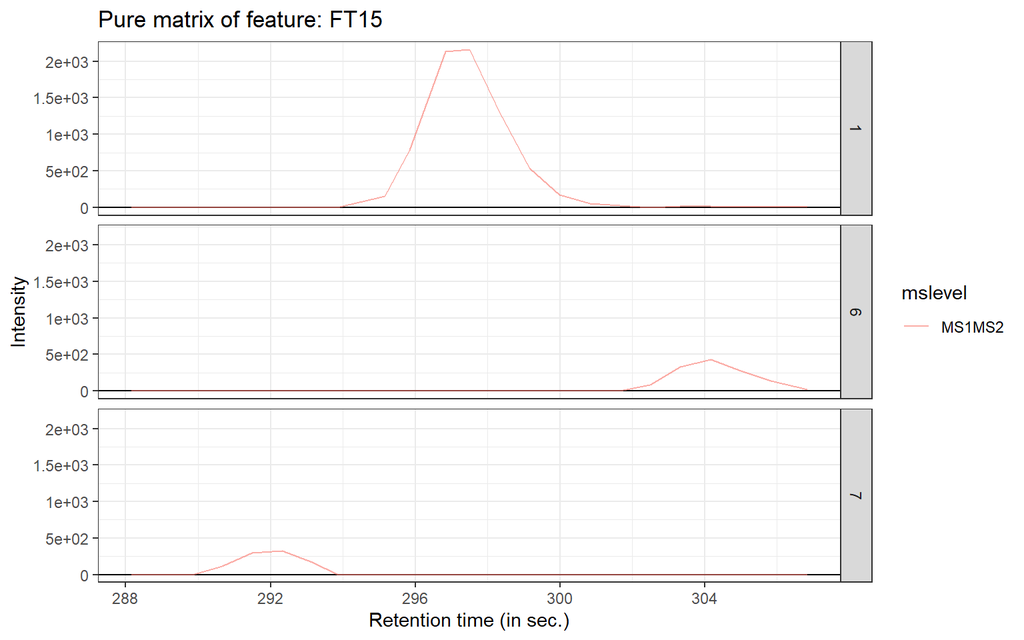

```r
# pure elution profiles plot
chrom <- plot_EluProfile(
    features.l = features,
    summary_dt = summary.dt,
    feature_id = scopolamine_id,
    sample_index = 1,
    log2L = FALSE,
    type = c("pure", "mixed")[1],
    method = c("all", "best")[1],
    max_method
  )
chrom
```

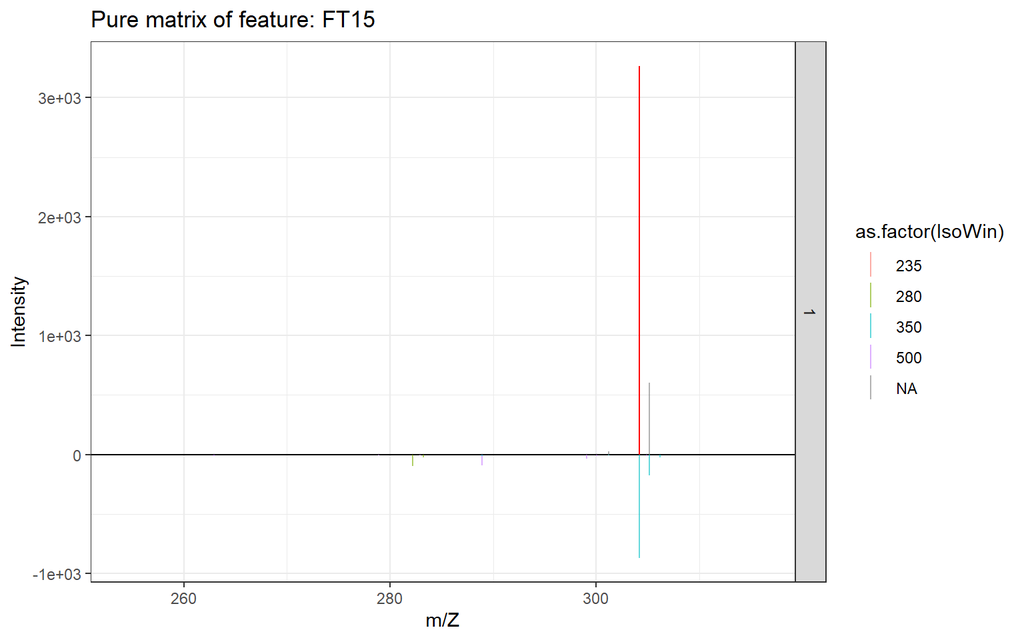

```r
# pure MS1 vs. MS2 spectra plot
spect1_p <- plot_Spectra(
    features.l = features,
    summary_dt = NULL,
    feature_id = scopolamine_id,
    sample_index = 1,
    log2L = F,
    type = c("pure", "mixed")[1],
    method = c("all", "best")[2],
    max_method
  )
spect1_p
```

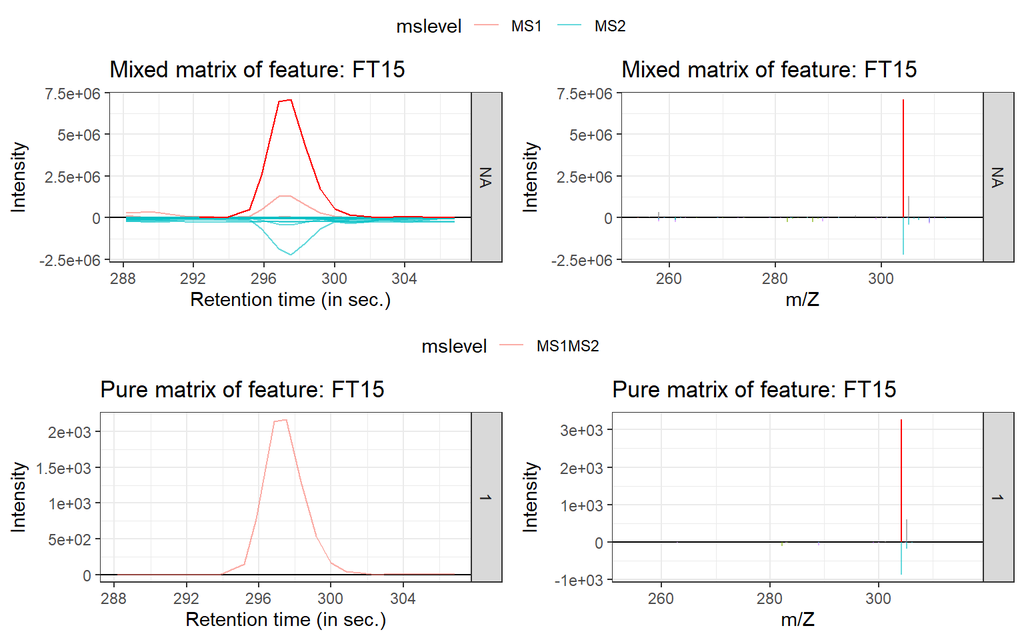

```r
# mixed and pure feature plot
feat_p <- plot_feature(
    features.l = features,
    summary_dt = summary.dt,
    feature_id = scopolamine_id,
    sample_index = 1,
    log2L = FALSE,
    max_method = "max_value",
    method = c("all", "best")[2]
  )
feat_p
```

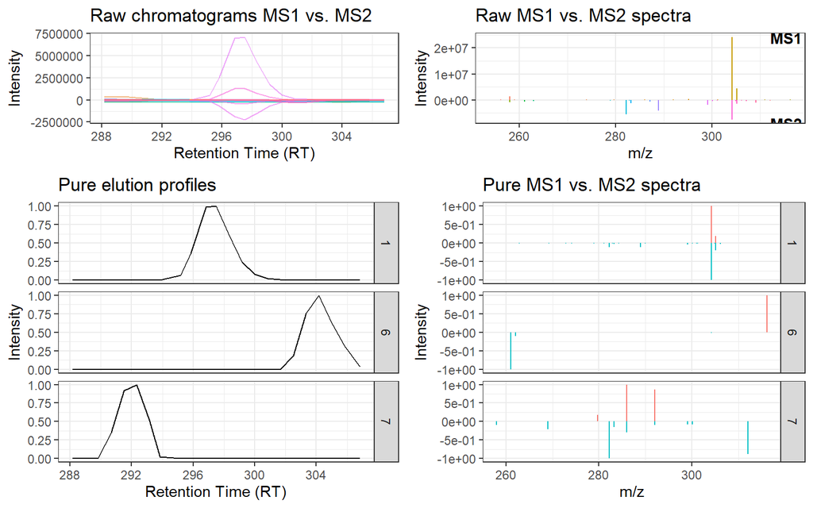

```r
# retention time window plot
rt_wind <- plot_rtWind_info(features.l = features, sample_index = 1, iteration_idx = 1, targets = NULL)
rt_wind_p <- rt_wind$p_final
rt_wind_p
```